# Econ 3040 - Computer Lab 1

Ryan Godwin

This tutorial will start getting you accustomed to R and RStudio. Please refer to Lecture Slides 1 for information on how to install R and RStudio. [R is a free software environment for statistical computing and graphics.](https://www.r-project.org/) R is one of the [fastest growing programming languages in the last 5 years, and is used in a wide array of industries.](https://stackoverflow.blog/2017/10/10/impressive-growth-r/) R has the advantage that it is free and open-source, and that thousands of users have contributed “add-on” packages that are readily downloadable by anyone. [RStudio](https://www.rstudio.com/) is a free extension to R, that we will be using for the course.

# Objectives

You will:

- Open RStudio
- Create a script file
- Use R as a calculator
- Create an object
- Explore simple functions in R
- Use logical operators
- Use indexing
- Load data
- Explore data
- Create histograms and scatterplots
- Create new variables
- Import your histogram, scatterplot, and table into a Word document
- Save your script file

# Open RStudio

Search your computer for RStudio.exe and open the program. It should look something like this:

[figure not shown]

# Create a script file

Click on “File”, “New File”, “R Script”.

- In the top left is your Script file. R commands can be run from the R Script file, and saved at any time.
- In the bottom left is the Console window. Output is displayed here. R commands can be run from the Console, but not saved.
- In the top right is the Environment. Data and variables will be visible here.
- The bottom right will display graphics (e.g. histograms and scatterplots).

[figure not shown]

# Use R as a calculator

R’s arithmetic operators include:

| Operator | Function |
| --- | --- |
| $+$ | addition |
| $-$ | subtraction |
| $*$ | multiplication |
| / | division |
| ^ | exponentiation |

Type the following command into your R script: `1 + 2`. Run the command by highlighting it, or making sure the cursor is active at the end of the line, and clicking ``Run’’.

[figure not shown]

Ignore the `[1]` that is printed out.

# Create an object

You can create objects in R. Objects can be vectors, matrices, character strings, data frames, etc. Create two different scalars (give them any name you like, it doesn’t have to be `a` and `b`):

```r
a <- 3
b <- 5
```

Note that you can copy-paste commands in the gray boxes directly into R.

We have created two new objects called `a` and `b`, and have assigned them values using the assignment operator `<-` (the “less than” symbol followed by the “minus” symbol). Notice that `a` and `b` pop up in the top-right of your screen. We can now refer to these objects by name:

```r
a * b
```

```
## [1] 15
```

To create a vector in R we use the “combine” function, `c()`:

```r
myvector <- c(1, 2, 4, 6, 7)
```

# Simple functions in R

To call a function in R, type the name of the function, and the arguments of the function in parentheses: `functionname(arguments)`.

There are thousands of functions in R. Here are a few that we’ll need:

| Function |
| --- |
| sum() |
| mean() |
| var() |
| summary() |

Try all of these functions on `myvector`. For example:

```r
sum(myvector)
```

```
## [1] 20
```

The `sum()` function is looking for arguments that it can add together. Put an object in the brackets, and the function will try to add. Try `mean(myvector)`. You can get help on a function by typing `?` followed by the function name, and running the command. For example, try `?summary`.

# Logical operators

Logical operators are used to determine whether something is `TRUE` or `FALSE`. Some logical operators are:

| Operator | Function |
| --- | --- |
| > | greater than |
| == | equal to |
| < | less than |
| >= | greater than or equal to |
| <= | less than or equal to |
| != | not equal to |

The operators `&` “and” and `|` “or” may be used to combine the above operators.

Try entering the following commands:

```r
8 > 4
```

```
## [1] TRUE
```

```r
b == 6
```

```
## [1] FALSE
```

```r
b > 2
```

```
## [1] TRUE
```

```r
myvector > 3
```

```
## [1] FALSE FALSE  TRUE  TRUE  TRUE
```

```r
myvector > 3 & myvector < 7
```

```
## [1] FALSE FALSE  TRUE  TRUE FALSE
```

For the last example, R has checked to see whether each element in `myvector` is greater than 3 and less than 7.

We will use these logical operators for “indexing”. It allows us to choose certain observations in the data set based on values of the variables. In other words, it allows us to “subset” the data.

# Indexing

Indexing allows us to extract parts of a vector, matrix, or data set. For example, to get the third value from `myvector` use:

```r
myvector[3]
```

```
## [1] 4
```

We need to create a matrix for the next example. Copy-paste the following command and run it (don’t worry about what it means, just do it):

```r
mymatrix <- matrix(c(rep(1:2,2), 1:8), 4, 3)
```

Again, you’ll see the object you created pop up in the top-right of your screen. Click the “spreadsheet” icon next to the data set to view it:

[figure not shown]

Close the “mymatrix” tab when you are done. You can also view an object by entering its name:

```r
mymatrix
```

```
##      [,1] [,2] [,3]
## [1,]    1    1    5
## [2,]    2    2    6
## [3,]    1    3    7
## [4,]    2    4    8
```

Suppose you want to extract the `6` from the matrix. You would ask for the 2nd row, 3rd column:

```r
mymatrix[2, 3]
```

```
## [1] 6
```

Suppose you wanted the entire 3rd row of the matrix. You would ask for the 3rd row, and all columns (leave a blank):

```r
mymatrix[3, ]
```

```
## [1] 1 3 7
```

Now, let’s combine indexing and logical operators. First, let’s see which elements in the first column are equal to 1:

```r
mymatrix[, 1] == 1
```

```
## [1]  TRUE FALSE  TRUE FALSE
```

and use this to get only the rows that have a 1 in their 1st column:

```r
mymatrix[mymatrix[, 1] == 1, ]
```

```
##      [,1] [,2] [,3]
## [1,]    1    1    5
## [2,]    1    3    7
```

On your own, try to extract only the rows for which the number in the 2nd column is greater than or equal to 2, and also less than 4.

`mymatrix[mymatrix[, 2] >= 2 & mymatrix[, 2] < 4, ]`

This will get easier when the columns have names.

# Load data

The data is in the “comma-separated-format” or “.csv”. This is a very simple and common format for storing data.

RStudio can read data from your computer, or from the internet. Load the data with:

```r
mydata <- read.csv("http://home.cc.umanitoba.ca/~godwinrt/data/vidsales.csv")
```

We have created a new object called `mydata`, and have assigned it the values in the `.csv` file using the assignment operator `<-`. You could have chosen a name different than `mydata`.

The `mydata` object shows up in the top-right of your screen. The sample size is 4706 and there are 8 variables.

Click the “spreadsheet” icon next to the data set to view it. Take a moment to look through the data, and make sure you have an idea of what each of the variables are. The `Sales` variable is either the total global sales of the game, or the sales from bundling with consoles, and is measured in millions of US dollars. `Score` is the critic score from video game reviewers, and is on a scale of 0 to 10, with 10 being best. Notice that each video game (each observation in the data set) takes up a different row, while the type of information on the video game (the variables) takes up a different column. Close the “data” tab when you are done viewing.

# Explore the data

Click the blue arrow next to `data` in the top-right of your screen.

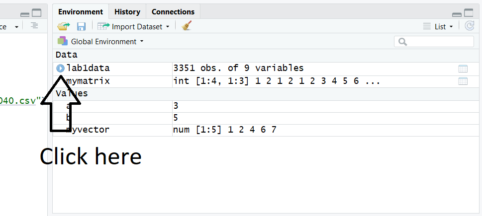

Each variable name is listed, along with some info. Notice that the variables each have a type:

| Name | Type |
| --- | --- |
| chr | A character string (words) |
| num | Any real (continuous) number. |
| int | Any integer. |

The “character” variables can be used to create dummy variables (more on this later!)

To explore the data, we can calculate “summary” statistics for all the variables:

```r
summary(mydata)
```

```
##      Name              Genre           ESRB_Rating          Platform
##  Length:4706        Length:4706        Length:4706        Length:4706
##  Class :character   Class :character   Class :character   Class :character
##  Mode  :character   Mode  :character   Mode  :character   Mode  :character
##
##
##
##   Publisher             Score           Sales             Year
##  Length:4706        Min.   : 1.00   Min.   : 0.010   Min.   :1985
##  Class :character   1st Qu.: 6.50   1st Qu.: 0.150   1st Qu.:2004
##  Mode  :character   Median : 7.50   Median : 0.420   Median :2008
##                     Mean   : 7.27   Mean   : 1.177   Mean   :2007
##                     3rd Qu.: 8.30   3rd Qu.: 1.100   3rd Qu.:2010
##                     Max.   :10.00   Max.   :82.860   Max.   :2020
```

The min, max, quartiles, and mean have been calculated. For example, the sample mean `Score` is 7.27.

We can extract variables from the data set, and perform functions on them. To calculate the sample variance for `Sales`:

```r
var(mydata$Sales)
```

```
## [1] 7.607421
```

**Important:** when we type `mydata$Sales` we are getting the `Sales` variable from within the `mydata` data set.

Now, calculate the correlation between `Sales` and `Score`:

```r
cor(mydata$Sales, mydata$Score)
```

```
## [1] 0.2634555
```

What does this tell you?

## Sub-sampling

We can use indexing, together with logical operators, to create sub-samples.

Nintendo is my favourite publisher. Let’s see their critic scores vs. the critic scores from other publishers:

```r
mean(mydata$Score[mydata$Publisher == "Nintendo"])
```

```
## [1] 7.799296
```

```r
mean(mydata$Score[mydata$Publisher != "Nintendo"])
```

```
## [1] 7.21722
```

Notice how we have used logical operators and indexing to create two sub-samples: Nintendo games, and other games.

On your own, determine the total global sales in the data set for the publisher “Rockstar Games”.

`sum(mydata$Sales[mydata$Publisher == "Rockstar Games"])`

Now, find all the video games that have received a perfect score of 10.

`mydata[mydata$Score == 10,]`

For the rest of the tutorial, we’ll use a sub-sample of all video games that have sales 2 million USD or more:

```r
vid2 <- mydata[mydata$Sales >= 2, ]
```

The above line creates a new data set, by selecting only the rows from `mydata` which have `Sales >= 2`, and by selecting all columns (notice the blank space in the brackets `[]` after the comma).The new data set shows up in the top-right panel. Check the sample size.

# Histograms and scatterplots

Visualization is important. Plot a histogram of critic scores:

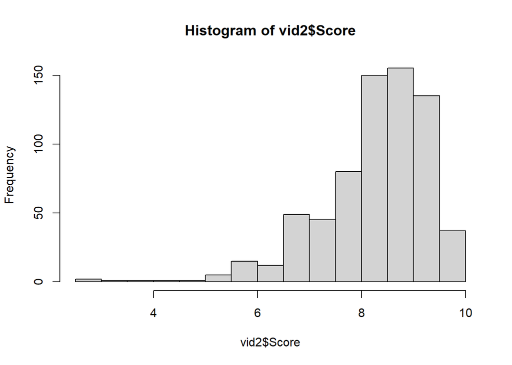

```r
hist(vid2$Score)
```

Many options are available to customize the histogram, see `?hist`. Let’s add some labels, and control the number of “breakpoints”:

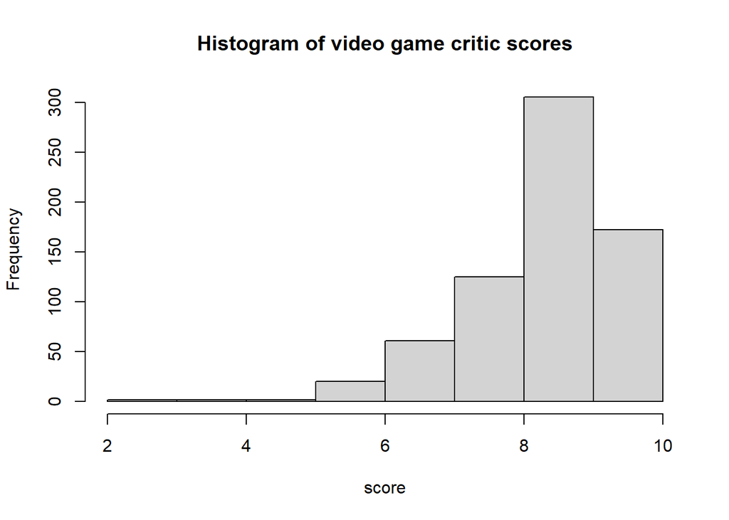

```r
hist(vid2$Score,
     main = "Histogram of video game critic scores",
     xlab = "score",
     breaks = 10)
```

The scatterplot is the most widely used tool for visualizing the relationship between two variables. Draw a scatterplot for `Sales` and `Score`, adding a title and labeling the axis:

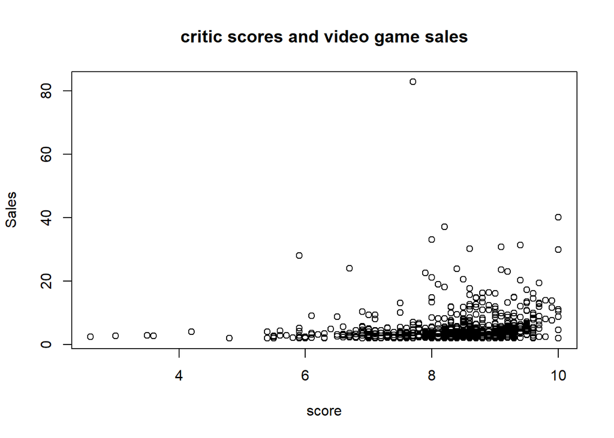

```r
plot(vid2$Score, vid2$Sales,
     main = "critic scores and video game sales",
     xlab = "score", ylab = "Sales")
```

We can also change the color and style of the dots:

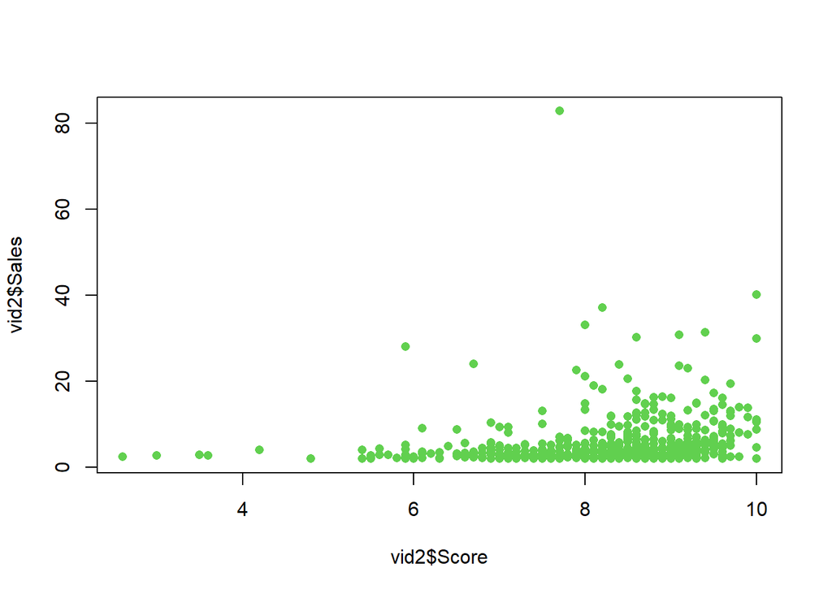

```r
plot(vid2$Score, vid2$Sales,
     col = 3,
     pch = 16)
```

Type `?pch` to see the different styles, and Google to see the different colours.

# Create new variables

Let’s create a new variable that we’ll use to select the colour of each data point. Make a new variable called `G` inside of the `vid2` dataset, and use `G` to control the colour of each data point. We begin by setting all rows of the variable equal to 1, and then change the value of `G` based on the game’s `Genre`. Copy and paste the code below:

```r
vid2$G <- 1
vid2$G[vid2$Genre == "Action"] <- 2
vid2$G[vid2$Genre == "Sports"] <- 3
vid2$G[vid2$Genre == "Shooter"] <- 7
vid2$G[vid2$Genre == "Role-Playing"] <- 4
vid2$G[vid2$Genre == "Platform"] <- 5
vid2$G[vid2$Genre == "Racing"] <- 6
```

For example, if `Genre` is equal to `"Action"`, the variable `G` gets a value of 2. Look at this `G` variable in the spreadsheet to understand what has happened, Now, use this variable to determine the colour for each data point:

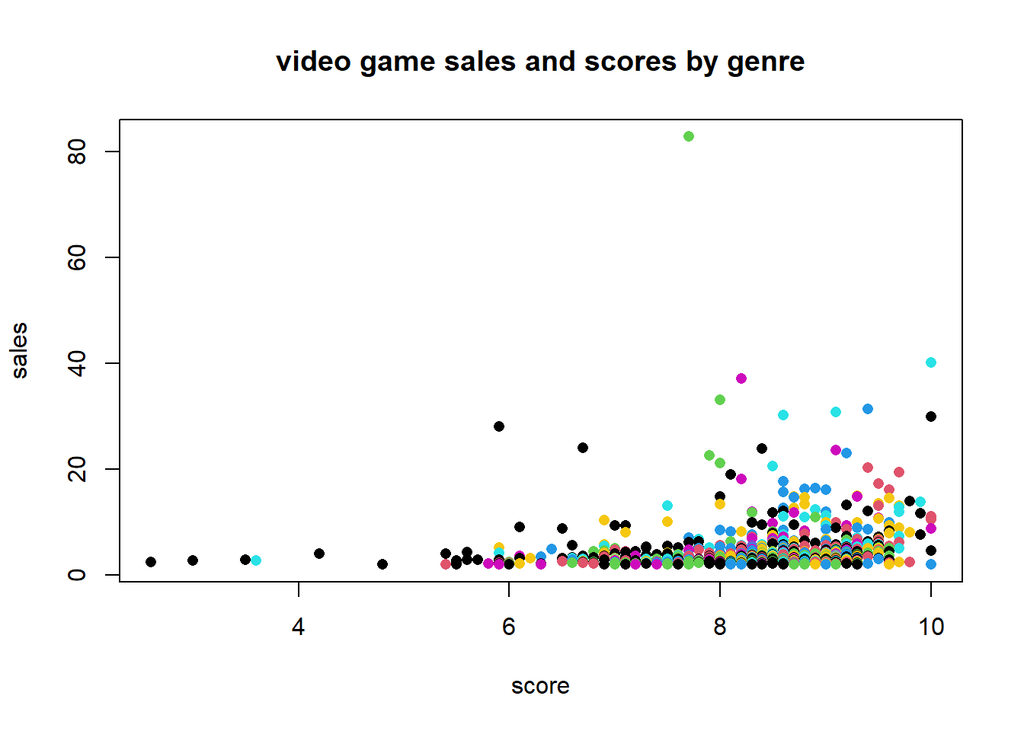

```r
plot(vid2$Score, vid2$Sales, col=vid2$G, pch=16,
     main = "video game sales and scores by genre",
     xlab = "score", ylab = "sales")
```

We need to add a legend to the plot to show what the colours mean:

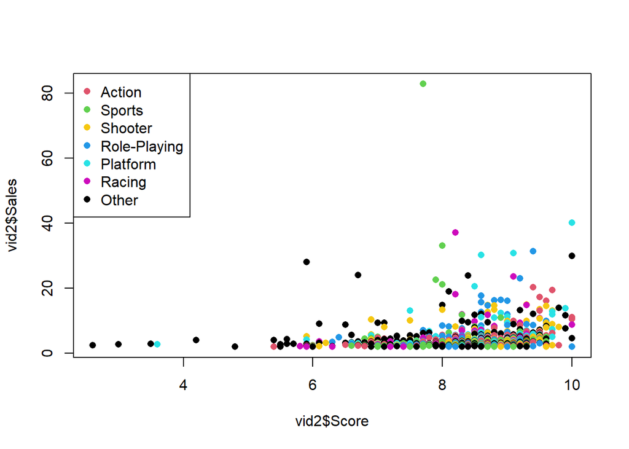

```r
plot(vid2$Score, vid2$Sales, col=vid2$G, pch=16)
legend("topleft",
       legend = c("Action", "Sports", "Shooter", "Role-Playing", "Platform", "Racing", "Other"),
       col=c(2, 3, 7, 4, 5, 6, 1), pch=16)
```

# Import your work into Word

In the “plots” window, click “Export” and “Save as Image…”. This way, you can import graphics you create into Word, or another word processor.

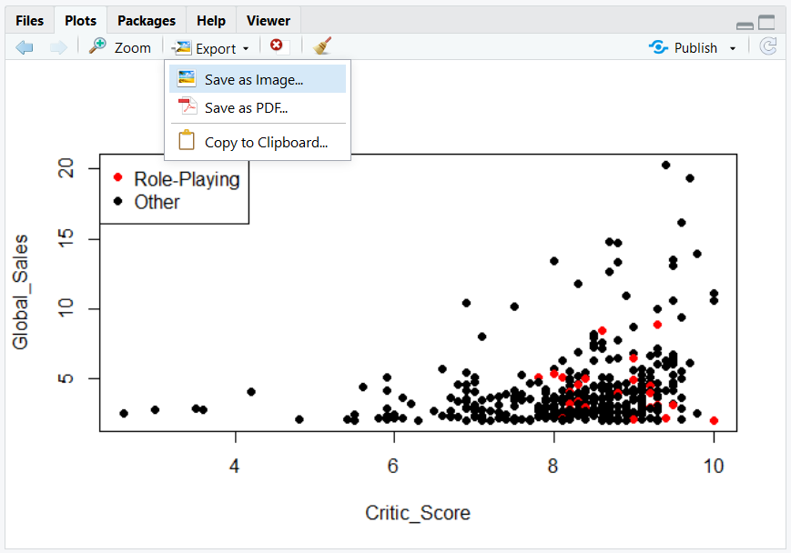

# Save your script file

Make sure the top-left window is active, then click “File”, “Save As…”, and name your script file.

# Clear your workspace

If you get too much junk floating around in R, you can clear the environment by clicking the “sweep” icon in the top-right, and start over.

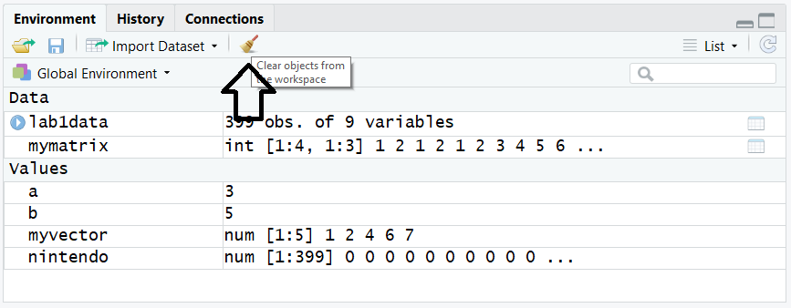